# Part II (students-performance-in-exam)

## by (Habibu Aminu Marafa)

## Investigation Overview

> In this investigation, I wanted to look at the exams performance of the students in various subjects. the main focus is on their gender and test preparation course

## Dataset Overview

> This dataset consist of the marks secured by the students in various subjects, including their gender, race/ethnicity, lunch, and test preparation course.

## Distribution of all the Scores.

> The plots are almost normal with some outliers. The score-peak for `reading_score` & `writing_score` is around 70 with `math_score` being around 65. That is to show more students perform well in the exams.

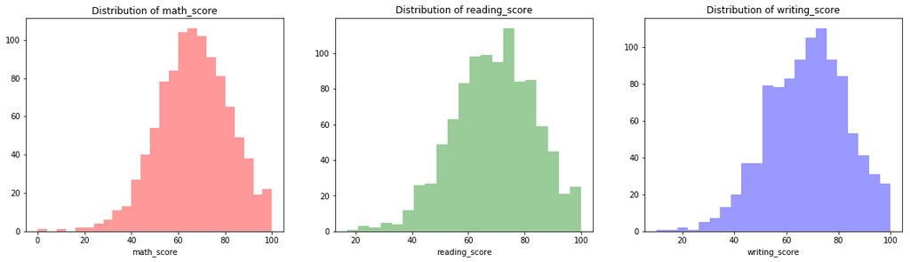

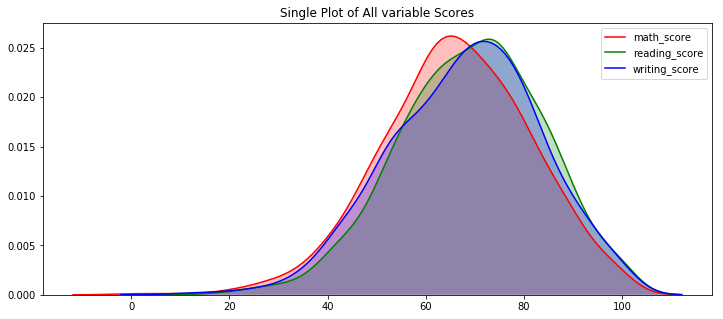

## Correlations between Numeric Features

> This shows that all the scores features are highly correlated with each other and so was percentage with all the score features because it is an engineered feature and calculated as an average of all the score values.

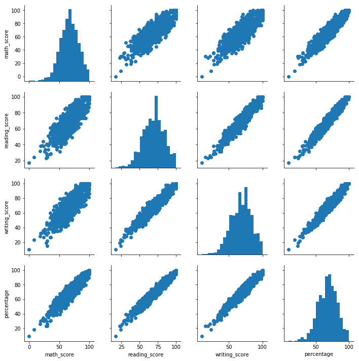

## Numeric Values Segregated by Gender

> This shows that female students overall have done better than male students. I think this can be because female students are more in number than male students in the datasets.

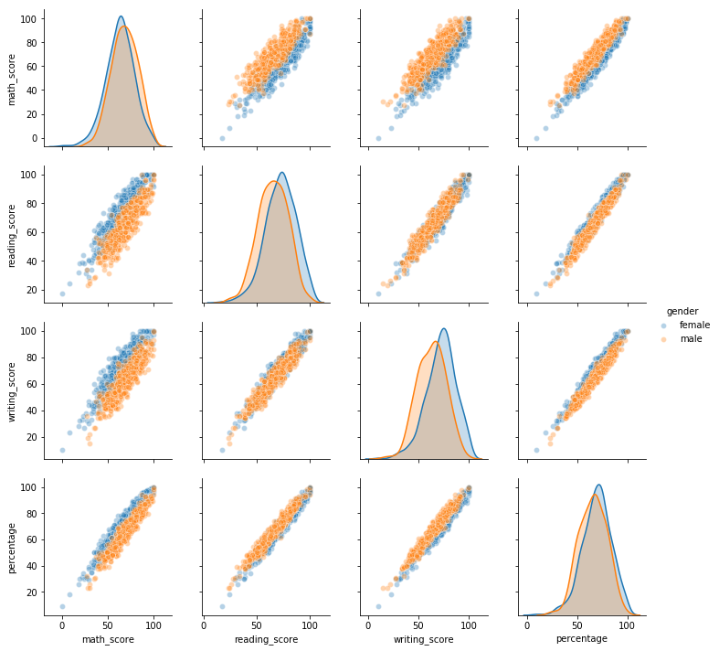

## Numeric Values Segregated by Test Preparation Course

> Here also students who have completed the test preparation course have done way better than those who haven't. This I can say it is like an assessement to get student prepared against exams.

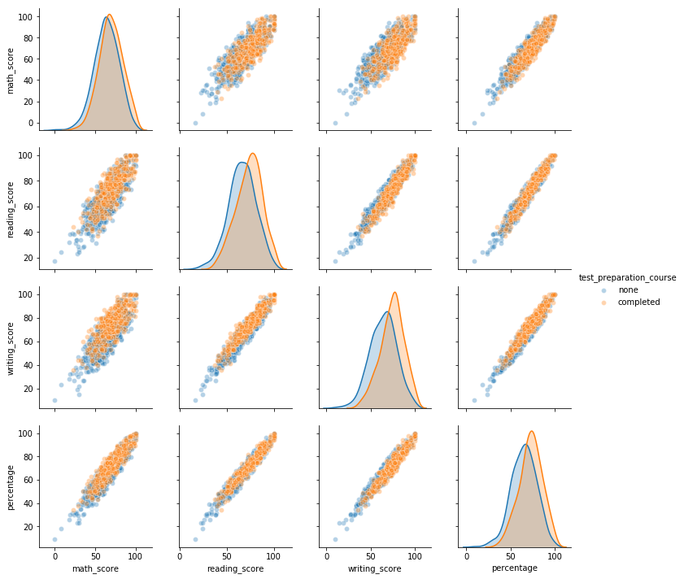

## Qualitative Variable with Percentage

> This explain further that students who completed the test_preparation_course scored high percentage. And female students did well in both the categories of test_prepar̥ation_course.

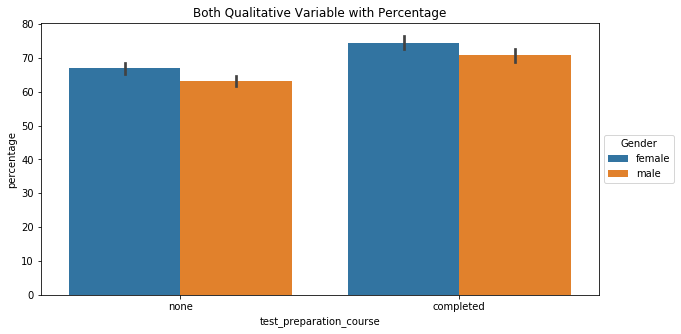